```python
cd ../Data
```

```
C:\Users\Frank\Jupyter Notebook\Udacity\dataScienceBlog\Data
```

```python
import pandas as pd
import numpy as np
import seaborn as sns
import matplotlib.pyplot as plt

import statsmodels.api as sm
from scipy import stats

from sklearn.naive_bayes import GaussianNB
from sklearn.ensemble import RandomForestClassifier
from sklearn.svm import SVC

from sklearn.model_selection import GridSearchCV
from sklearn.multioutput import MultiOutputClassifier
from sklearn.pipeline import Pipeline

from sklearn.metrics import accuracy_score
from sklearn.model_selection import train_test_split
from sklearn.metrics import classification_report
```

# business understanding

barges are vessel focused on the transportation of goods over inland waterways. In Western-Europe barges account for 34% of the transports. The market itself runs on independent barge operators who are provided with cargo assignments by brokers. Having a database of barges with fundamental information, namely length, width and cargo capacity in volume and tonnage helps brokers to find a suitable barge for an assignment.

Online resources like vessel finder have this kind of information. For a broker the question would be:

1. Is the information of an online resource like vessel finder complete?
2. If it isn't, is it possible to fill the missing values with an reliable etimation?
3. Can we have this data in a accessable format used by brokers like .csv or .xlxs

To answer these business questions research is done into a subset of barge information, retrieved from vessel finder. The information is analyzed, cleaned before predictions are made and results are stored.

## Data Understanding

For the recommendation of barge voyages, the information of barges are necessary. Barge choices are restricted by the specification of barges like the amount of tonnage it can carry or the waterways it can travel on. For an best prediction this information should be as detailed an complete as possible.

In the analysis and clean up phase information about barges are gathered, analysed and cleaned.

### Gather

The data was gather from vessel finder by a stakeholder and delivered in the form of a csv file

```python
df = pd.read_csv('barges_source.csv')
```

```python
df.info()
```

```
<class 'pandas.core.frame.DataFrame'>
RangeIndex: 595 entries, 0 to 594
Data columns (total 8 columns):
 #   Column        Non-Null Count  Dtype
---  ------        --------------  -----
 0   Unnamed: 0    595 non-null    int64
 1   Name          595 non-null    object
 2   capacityTon   370 non-null    float64
 3   capacityM3    359 non-null    float64
 4   lengthCm      588 non-null    float64
 5   widthCm       585 non-null    float64
 6   maxDraughtCm  360 non-null    float64
 7   minDraughtCm  360 non-null    float64
dtypes: float64(6), int64(1), object(1)
memory usage: 37.3+ KB
```

```python
df[['capacityTon', 'capacityM3','lengthCm','widthCm','maxDraughtCm','minDraughtCm']]
```

|  | capacityTon | capacityM3 | lengthCm | widthCm | maxDraughtCm | minDraughtCm |
| --- | --- | --- | --- | --- | --- | --- |
| 0 | 2673.0 | 2900.0 | 10999.0 | 1145.0 | 320.0 | 95.0 |
| 1 | 1362.0 | 1500.0 | 8597.0 | 950.0 | 279.0 | 140.0 |
| 2 | NaN | NaN | 8100.0 | 899.0 | NaN | NaN |
| 3 | NaN | NaN | 8400.0 | 960.0 | NaN | NaN |
| 4 | NaN | NaN | 8600.0 | 1100.0 | NaN | NaN |
| ... | ... | ... | ... | ... | ... | ... |
| 590 | NaN | NaN | NaN | NaN | NaN | NaN |
| 591 | 2660.0 | 3010.0 | 10988.0 | 1144.0 | 325.0 | 124.0 |
| 592 | 2789.0 | 3025.0 | 11000.0 | 1145.0 | 336.0 | 120.0 |
| 593 | 2540.0 | 3387.0 | 10983.0 | 1145.0 | 323.0 | 110.0 |
| 594 | 3366.0 | 3747.0 | 11000.0 | 1145.0 | 382.0 | 125.0 |

595 rows × 6 columns

There're 595 barges available. Goal is to create a ship recommendation system. Based on a voyage, from > to, which ship would be recommended? Therefore the following fields are interesting:

- capacityTon: How much ton of product a vessel can transport
- capacityM3: Hom much volume of a product a vessel can transport
- lengthCm: self explanatory
- widthCm: self explanatory
- maxDraughtCm: The maximum draught under the vessel that's permitted. Is valuable regarding water levels and cargo carrage
- minDraughtCm: The maximum draught under the vessel that's permitted. Is valuable regarding water levels and cargo carrage

Relevant for planning but out of scope for this assignment Classification: All vessels are barge (inland shipping) equiped to transport wet bulk. yearOfbuild: Interesting but no information yearLastMaintenance: Interesting but no information

## Functions to use for exploring the data

```python
def percentage_empty(variable, df = df):
    '''
    Function to count the amount of na for a certain information variable.

    input:
    Variable - column name of variable
    df - dataframe

    output:
    percentage and amount non values
    '''
    na_sum = sum(df[variable].isna())
    df_size = df.shape[0]

    amount = "The amount of non-values of {}:{}".format(variable,na_sum)
    percentage = "The percentage of non-values of {}:{}".format(variable,round(na_sum/df_size,2))

    return print(amount), print(percentage);
```

```python
def correlation_visualization(x,y):
    '''
    Plotting a regression line between two entities to visualize the correlation
    input:
    two entities
    output:
    Visualization
    '''

    sns.regplot(data = df, x = x, y = y, scatter_kws = {'alpha': 0.5})

    return plt.title('Relation between {} and {}'.format(x,y));
```

```python
def ols_results(x,y,z,df = df):
    '''
    Get OLS result from entities in data.
    Input:
    df - Dataframe used
    x - the entity we want to predict
    y - the entities we want to use to predict

    '''

    df_reg = df.copy()
    df_reg = df_reg[df_reg[x].notna()]
    df_reg = df_reg[df_reg[y].notna()]


    df_reg['intercept'] = 1

    logit_mod = sm.OLS(df_reg[x], df_reg[['intercept',y,z]])
    results = logit_mod.fit()

    return results.summary()
```

## Exploring barge capacity

The barge has a loading capacity. Because this data set is focussed on barge carrying liquid bulk both tonnage as m3 are measured.

```python
df[['capacityTon','capacityM3']].info()
```

```
<class 'pandas.core.frame.DataFrame'>
RangeIndex: 595 entries, 0 to 594
Data columns (total 2 columns):
 #   Column       Non-Null Count  Dtype
---  ------       --------------  -----
 0   capacityTon  370 non-null    float64
 1   capacityM3   359 non-null    float64
dtypes: float64(2)
memory usage: 9.4 KB
```

```python
print('capacityTon')
percentage_empty('capacityTon')
print('\ncapacityM3')
percentage_empty('capacityM3')
```

```
capacityTon
The amount of non-values of capacityTon:225
The percentage of non-values of capacityTon:0.38

capacityM3
The amount of non-values of capacityM3:236
The percentage of non-values of capacityM3:0.4
```

```
(None, None)
```

More than a third of the datafields are missing for the barge capacity information. This a significant number, dropping +30% of the data. Still, if we can't fill in the other information with online data or calculations this will be the only answer.

```python
df[['capacityTon','capacityM3']].describe()
```

|  | capacityTon | capacityM3 |
| --- | --- | --- |
| count | 370.000000 | 359.000000 |
| mean | 3028.194595 | 3502.955432 |
| std | 1628.937965 | 1716.044234 |
| min | 48.000000 | 643.000000 |
| 25% | 1748.250000 | 1985.000000 |
| 50% | 2813.000000 | 3352.000000 |
| 75% | 3457.500000 | 4135.000000 |
| max | 9950.000000 | 10220.000000 |

The capacity of both entities are roughly betwee the 0 - 10 000 with an standard deviation between the 1 600 and 1 700, which can be usefull when cleaning the data.

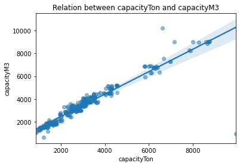

```python
correlation_visualization('capacityTon','capacityM3');
```

As expected, the correlation between capacityTon and capacityM3 is very high.

# Exploring barge measurements

A barge have a measure, which could have an influence on the capacities. barges are between the 60 and 180 meters in length and 10 to 20 meter in width. This can be found [here](https://www.bureauvoorlichtingbinnenvaart.nl/wp-content/uploads/2021/04/Scheepstypes_BVB_nieuw1.pdf)

```python
df[['lengthCm','widthCm']].info()
```

```
<class 'pandas.core.frame.DataFrame'>
RangeIndex: 595 entries, 0 to 594
Data columns (total 2 columns):
 #   Column    Non-Null Count  Dtype
---  ------    --------------  -----
 0   lengthCm  588 non-null    float64
 1   widthCm   585 non-null    float64
dtypes: float64(2)
memory usage: 9.4 KB
```

The data for length and width seems complete.

```python
df[['lengthCm','widthCm']].describe()
```

|  | lengthCm | widthCm |
| --- | --- | --- |
| count | 588.000000 | 585.000000 |
| mean | 10366.064626 | 1105.193162 |
| std | 1829.599328 | 180.165170 |
| min | 1996.000000 | 660.000000 |
| 25% | 8589.250000 | 960.000000 |
| 50% | 10990.000000 | 1140.000000 |
| 75% | 11000.000000 | 1145.000000 |
| max | 18000.000000 | 1760.000000 |

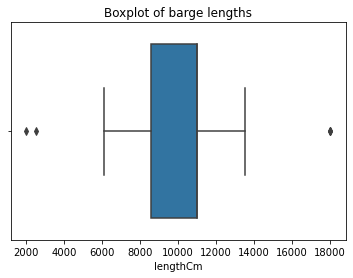

```python
sns.boxplot(data = df, x = 'lengthCm')
plt.title('Boxplot of barge lengths');
```

Overall the lengths seems to be okay. There is an outlier for the largest barge, with 18000 cm (180m), but this isn't uncommon. Especially for push barge with push units. A length of 20 - 40 howevers seems to be the push barges, without the push units. This wouldn't be helpfull in recommending a barge. We should check that data.

```python
df[df['lengthCm'] < 6000].index
```

```
Int64Index([415, 549], dtype='int64')
```

This information is unclear. A quick google [search](https://www.google.com/search?q=Hermanna+binnenvaartschip&source=lmns&bih=997&biw=832&rlz=1C1CHBF_nlNL879NL879&hl=nl&sa=X&ved=2ahUKEwiKsre2gIPxAhX0JMUKHSw7AY4Q_AUoAHoECAEQAA) shows that the Hermanna is a push barge. This data should be adjusted as such.

The till barge seems incorrect. Should adjust.

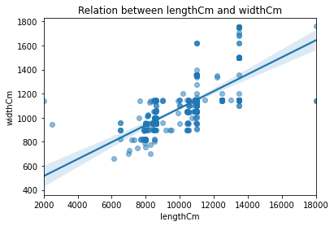

```python
correlation_visualization('lengthCm','widthCm');
```

As could be expected the length and width of a barge has a strong relationship.

## Exploring barge Draught

The draught of the barge is the room there is between the bottom of the barge and the ground. There's a max and a min. Max meaning when a barg is empty and min when a barge is full.

```python
df[['maxDraughtCm','minDraughtCm']].info()
```

```
<class 'pandas.core.frame.DataFrame'>
RangeIndex: 595 entries, 0 to 594
Data columns (total 2 columns):
 #   Column        Non-Null Count  Dtype
---  ------        --------------  -----
 0   maxDraughtCm  360 non-null    float64
 1   minDraughtCm  360 non-null    float64
dtypes: float64(2)
memory usage: 9.4 KB
```

```python
df[['maxDraughtCm','minDraughtCm']].describe()
```

|  | maxDraughtCm | minDraughtCm |
| --- | --- | --- |
| count | 360.000000 | 360.000000 |
| mean | 435.536111 | 134.977778 |
| std | 1579.491410 | 60.811133 |
| min | 185.000000 | 64.000000 |
| 25% | 315.000000 | 100.000000 |
| 50% | 349.000000 | 130.000000 |
| 75% | 382.000000 | 155.000000 |
| max | 30300.000000 | 622.000000 |

Seems like the max draught has a data entry problem with a max value that is out of proportion.

```python
print('maxDraughtCm')
percentage_empty('maxDraughtCm')
print('\nminDraughtCm')
percentage_empty('minDraughtCm')
```

```
maxDraughtCm
The amount of non-values of maxDraughtCm:235
The percentage of non-values of maxDraughtCm:0.39

minDraughtCm
The amount of non-values of minDraughtCm:235
The percentage of non-values of minDraughtCm:0.39
```

```
(None, None)
```

With a third of the data missing, the draught data could be missing with to much.

### Assess

Based on the data understanding we can make the following assessments:

- A third of the barges is missing capacity data, which is a lot. Capacity is important to decide if cargo can be transported
- The measurements are complete. There're two barges with not a lot of info.
- A third of the barges is missing draught data and the maxDraught has a outlier.

# Cleaning

## Measurement

- Drop barge without width
- Drop barge with strange lengths (id 415, 549)

```python
# Drop barges with empty values
df = df.dropna(subset = ["widthCm"])
```

```python
# Drop barges with strange lengths
df = df.drop(index = [415,549], errors = 'ignore')
```

## Capacity

check if capacity can be filled with measurements

```python
def comparisonTonnageVolume(df,primaryColor, secondaryColor):
    '''
    compare tonnage and volumes to see pattern

    :param df: dataframe of barges
    :param primaryColor: color for tonnage
    :param secondaryColor: color for volume
    :return: shows comparison
    '''

    capTonM3Overlap = df[df['capacityTon'].notna() & df['capacityM3'].notna()]['capacityTon'].count()
    capTonNotOverlapM3 = df[df['capacityTon'].notna() & df['capacityM3'].isna()]['capacityTon'].count()
    capM3NotOverlapTon = df[df['capacityTon'].isna() & df['capacityM3'].notna()]['capacityTon'].count()

    print("In {} cases the capacity ton and M3 overlap".format(capTonM3Overlap))
    print("A percentage of {} the fleet has both capacity ton and M3".format(
        round(capTonM3Overlap / df.shape[0], 2) * 100))
    print("In {} cases the capacity ton has values but the M3 is null".format(capM3NotOverlapTon))
    print("In {} cases the capacity ton is null but the M3 has values".format(capTonNotOverlapM3))

    plt.figure(figsize=(15, 8))
    ax = sns.histplot(df["capacityTon"], kde=True, color=primaryColor)
    sns.histplot(df["capacityM3"], color=secondaryColor, kde=True)
    plt.legend(['capacityTon', 'categoryM3'])
    plt.title('Distribution of capacities for capacityTon and capacityM3')
    ax.set(xlabel='capacity_amount')

    plt.show()
```

```
In 358 cases the capacity ton and M3 overlap
A percentage of 61.0 the fleet has both capacity ton and M3
In 0 cases the capacity ton has values but the M3 is null
In 10 cases the capacity ton is null but the M3 has values
```

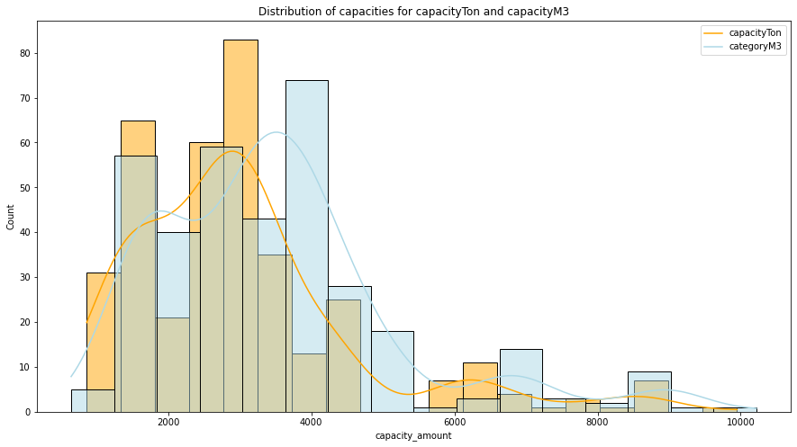

```python
comparisonTonnageVolume(df,'orange','lightBlue')
```

When searching for a barge, the loading capacity, mainly the tonnage or volume, are important filters. Therefore it's a necassity to have this information filled.

During the analysis we've seen a strong relationship between the tonnage and the volume. This could help with filling the na values, but this is only valuable for 10 extra barges. We could also use other dimensions like length, width and depth. Perhaps depth can be deducted from the draught data.

```python
# Get square meters of barges
df['barge_M2'] = df['lengthCm'] * df['widthCm']
```

```python
def categorizer(variable,maxi,mini):
    '''
    Function to group barge capacities. Per 500 unit rounded up actual capacity.
    For instance a barge with capacityTon of 1.245 will grouped in 1000, because it can carry 1.000 ton
    For instance a barge with capacityM3 of 5.955 will grouped in 5.500, because it can carry 5.500 M3

    input:
    variable - list of capacities
    output:
    cat_list - variables catagorized
    '''

    cat_list = []
    step = int((maxi - mini) / 20)

    for i in variable:
        #if barge hasn't have a capacity fill na
        if np.isnan(i):
            cat_list.append(np.nan)
        else:
            # determine treshold based on min and max values
            for treshold in list(range(mini,maxi + step ,step)):
                if i <= treshold:
                    thisSize = treshold  #round off because cargo should fit the barge
                    cat_list.append(thisSize)
                    break

    return cat_list
```

```python
df['categoryM2'] = categorizer(df['barge_M2'],int(df['barge_M2'].max()),int(df['barge_M2'].min()))
```

```python
#catageorize the capacities with unit of 500. for instance: 500ton, 1000ton, 1500ton, etc.
df['categoryTon'] = categorizer(df['capacityTon'],int(df['capacityTon'].max()),int(df['capacityTon'].min()))
df['categoryM3'] = categorizer(df['capacityM3'],int(df['capacityM3'].max()),int(df['capacityM3'].min()))
```

```python
df[['categoryTon','categoryM3','barge_M2']].info()
```

```
<class 'pandas.core.frame.DataFrame'>
Int64Index: 583 entries, 0 to 594
Data columns (total 3 columns):
 #   Column       Non-Null Count  Dtype
---  ------       --------------  -----
 0   categoryTon  368 non-null    float64
 1   categoryM3   358 non-null    float64
 2   barge_M2     583 non-null    float64
dtypes: float64(3)
memory usage: 18.2 KB
```

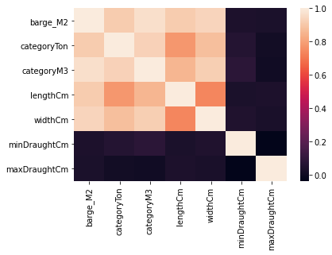

```python
# Create heatmap with correlations to signal possible indicators
sns.heatmap(df[['barge_M2','categoryTon','categoryM3','lengthCm','widthCm','minDraughtCm','maxDraughtCm']].corr());
```

There seems to bee a strong correlation between the lenght, width, square meters and capacities. The draught information however doesn's seem to correlate with the other data points. Let's further explore the first.

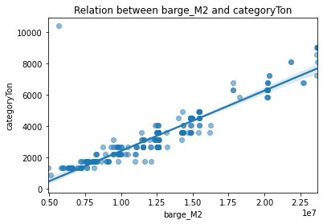

```python
correlation_visualization('barge_M2','categoryTon')
```

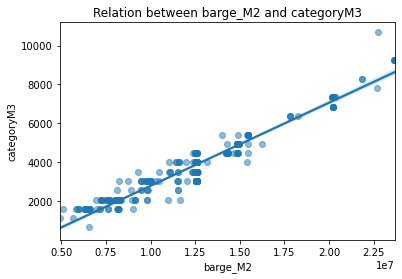

```python
correlation_visualization('barge_M2','categoryM3')
```

```python
ols_results('categoryM3','categoryTon','barge_M2', df)
```

OLS Regression Results

| Dep. Variable: | categoryM3 | R-squared: | 0.945 |
| --- | --- | --- | --- |
| Model: | OLS | Adj. R-squared: | 0.945 |
| Method: | Least Squares | F-statistic: | 3060. |
| Date: | Sun, 18 Jul 2021 | Prob (F-statistic): | 1.47e-224 |
| Time: | 14:17:26 | Log-Likelihood: | -2659.1 |
| No. Observations: | 358 | AIC: | 5324. |
| Df Residuals: | 355 | BIC: | 5336. |
| Df Model: | 2 |  |  |
| Covariance Type: | nonrobust |  |  |

|  | coef | std err | t | P>\|t\| | [0.025 | 0.975] |
| --- | --- | --- | --- | --- | --- | --- |
| intercept | -1067.6801 | 84.202 | -12.680 | 0.000 | -1233.277 | -902.083 |
| categoryTon | 0.2954 | 0.032 | 9.175 | 0.000 | 0.232 | 0.359 |
| barge_M2 | 0.0003 | 1.36e-05 | 23.044 | 0.000 | 0.000 | 0.000 |

| Omnibus: | 74.991 | Durbin-Watson: | 1.715 |
| --- | --- | --- | --- |
| Prob(Omnibus): | 0.000 | Jarque-Bera (JB): | 1122.807 |
| Skew: | -0.324 | Prob(JB): | 1.53e-244 |
| Kurtosis: | 11.652 | Cond. No. | 4.99e+07 |

Notes:  
[1] Standard Errors assume that the covariance matrix of the errors is correctly specified.  
[2] The condition number is large, 4.99e+07. This might indicate that there are  
strong multicollinearity or other numerical problems.

```python
ols_results('categoryTon','categoryM3','barge_M2',df)
```

OLS Regression Results

| Dep. Variable: | categoryTon | R-squared: | 0.868 |
| --- | --- | --- | --- |
| Model: | OLS | Adj. R-squared: | 0.867 |
| Method: | Least Squares | F-statistic: | 1164. |
| Date: | Sun, 18 Jul 2021 | Prob (F-statistic): | 1.24e-156 |
| Time: | 14:17:26 | Log-Likelihood: | -2799.9 |
| No. Observations: | 358 | AIC: | 5606. |
| Df Residuals: | 355 | BIC: | 5617. |
| Df Model: | 2 |  |  |
| Covariance Type: | nonrobust |  |  |

|  | coef | std err | t | P>\|t\| | [0.025 | 0.975] |
| --- | --- | --- | --- | --- | --- | --- |
| intercept | -463.7977 | 148.377 | -3.126 | 0.002 | -755.605 | -171.990 |
| categoryM3 | 0.6488 | 0.071 | 9.175 | 0.000 | 0.510 | 0.788 |
| barge_M2 | 0.0001 | 3.13e-05 | 3.477 | 0.001 | 4.73e-05 | 0.000 |

| Omnibus: | 653.683 | Durbin-Watson: | 1.894 |
| --- | --- | --- | --- |
| Prob(Omnibus): | 0.000 | Jarque-Bera (JB): | 444049.184 |
| Skew: | 10.905 | Prob(JB): | 0.00 |
| Kurtosis: | 174.152 | Cond. No. | 5.94e+07 |

Notes:  
[1] Standard Errors assume that the covariance matrix of the errors is correctly specified.  
[2] The condition number is large, 5.94e+07. This might indicate that there are  
strong multicollinearity or other numerical problems.

## Draught

min and max draught could be interesting data points if they would offer an indication about the barge capacity or measurements. unfortunately there doesn't seem to be a strong correlation. Because this is the case, we won't consider this information any further in the analysis and prediction.

## Conclude and analyse

After cleaning the data and analysing the substance we can conclude that:

1. The sqaure meters of a barge has a strong relationship with the capacity of the barge
2. The min and max draught of a barge doesn't have a strong relationship with the capacity of a barge
3. The capacity ton and volume have a strong relationship with eachother.

Go further, we should consider to build a model based on the square meters of the barge, her capacity ton and capacity volume. Because the prediction rate of volume is stronger we should consider predicting this value before that of ton.

# Modeling

## Selecting a classifier for the model

```python
# Because the new values will be placed based on index, the index has to be reset
df.reset_index(drop=True, inplace=True)
```

```python
def train_data():
    '''
    create training data
    '''
    tdf = dataframe.copy()

    # remove null values to prevent errors
    tdf = tdf[tdf['categoryTon'].notna()]
    tdf = tdf[tdf['categoryM3'].notna()]

    #remove outliers from features to enhance the trainingset
    tdf = tdf[(np.abs(stats.zscore(tdf[features])) < 3)]

    label = tdf[label]
    features = tdf[features]


    features_train, features_test, labels_train, labels_test = train_test_split(features, label, test_size=0.2, random_state=42)

    return features_train, features_test, labels_train, labels_test
```

```python
def trainingset(dataframe, label, features = []):
    '''
    Function to create a trainingset
    Input:
    Dataframe - Dataframe
    Label - column in dataframe of which the values are to be predicted
    Features - columns in dataframe that are used to predict labels
    '''

    tdf = dataframe.copy()

    # remove null values to prevent errors
    tdf = tdf[tdf['categoryTon'].notna()]
    tdf = tdf[tdf['categoryM3'].notna()]

    #remove outliers from features to enhance the trainingset
    tdf = tdf[(np.abs(stats.zscore(tdf[features])) < 3)]

    label = tdf[label]
    features = tdf[features]

    features_train, features_test, label_train, label_test = train_test_split(features,label, test_size=0.2)

    return features_train, features_test, label_train, label_test



def prediction(clf,dataframe, label, features = []):
    '''
    Get the accuracy of a prediction based on a classifier model inserted
    input:
    clf - classifier model to insert. Compatibel with GaussianNB(),SVC(),RandomForestClassifier()
    dataframe
    Dataframe - Dataframe
    Label - column in dataframe of which the values are to be predicted
    Features - columns in dataframe that are used to predict labels
    '''

    features_train, features_test, label_train, label_test = trainingset(dataframe, label, features)

    clf.fit(features_train, label_train)
    pred = clf.predict(features_test)
    accuracy = accuracy_score(pred, label_test)

    return clf, accuracy
```

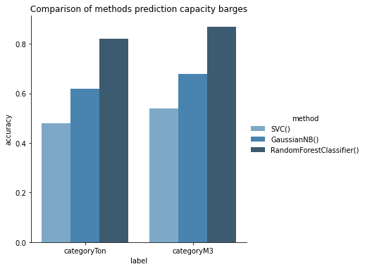

```python
pred_method = [GaussianNB(),SVC(),RandomForestClassifier()]
pred_label = ['categoryM3','categoryTon']
cmp_method = {}

#create a dictionary with results of different prediction methods
for method in pred_method:
    for label in pred_label:
        if label == 'categoryTon':
            clf, acc = prediction(method,df,label,['categoryM3','barge_M2'])
            cmp_method_items = {'method': method, 'label': label, 'accuracy':round(acc,2)}
        elif label == 'categoryM3':
            clf, acc = prediction(method,df,label,['categoryTon','barge_M2'])
            cmp_method_items = ({'method': method, 'label': label, 'accuracy':round(acc,2)})

        key = 0
        if not cmp_method:
            key = 0
        else:
            key = list(cmp_method.keys())[-1] + 1
        cmp_method[key] = cmp_method_items

# place dictionary in a dataframe an plot results
methd_df = pd.DataFrame.from_dict(cmp_method, orient='index').sort_values('accuracy')

ax = sns.catplot(data=methd_df, x="label", y="accuracy", hue="method", kind="bar", palette="Blues_d")
plt.title('Comparison of methods prediction capacity barges');
```

The plot shows that the RandomForestClassifier() is the best method of these three. We should further investigate

## Building the model

```python
def build_rfc_model():
    '''
    Build a model that can search trough and compare parameters for a RandomForrestClassifier
    input:
    None
    output:
    GridSearchCV that can be used to fit a model on
    '''

    parameters = {
                    'n_estimators' : [100,250,500],
                    'max_features': ['log2','auto']
                 }
    ensemble = RandomForestClassifier()
    clf = GridSearchCV(ensemble, parameters)

    return clf

def evaluate_rfc_model(model, features_test, label_test,label):
    '''
    Evaluation model that takes information and goes through parameters of
    the machine learning model to see which are optimal.
    Input:
    Model - Model build in the build_rfc_function
    Features_test - data set for test features
    Label_test - data set voor test labels
    Output:
    Print - the performance of the model based on the scores prediction, reclass and F1
    model.best_params_ - best parameters for the model
    '''

    label_prediction = model.predict(features_test)
    print(classification_report(label_test, label_prediction))
    print(model.best_params_)


    return model.best_params_


def process_operator(dataframe,label,features = []):
    '''
    Function that operates the process to create a model for predictions
    Input:
    Dataframe - Dataframe
    Label - column in dataframe of which the values are to be predicted
    Features - columns in dataframe that are used to predict labels
    '''

    print('Get trainingset...')
    features_train, features_test, label_train, label_test = trainingset(dataframe, label, features)

    print('Building model...')
    model = build_rfc_model()

    print('Training model...')
    model.fit(features_train, label_train)

    print('Evaluating model...')
    rfc_clf = evaluate_rfc_model(model, features_test, label_test, label)

    return rfc_clf
```

```python
def fillNaWithRFC(dataframe,columnsWithNa,label,features = []):
    '''
    functions to predict missing values based on a RandomForrestClassifier algoritme
    and add those to the current dataframe.
    input:
    '''


    # Create features for missing categoryM3
    featuresClassifier = dataframe[(dataframe[label].isna()) & (dataframe[features[0]].notna())][features]
    indexValues = dataframe[(dataframe[label].isna()) & (dataframe[features[0]].notna())][features].index


    # Create model for prediction
    print('start process operator')
    clf_parameters = process_operator(dataframe,label,features)
    clf_rfc = RandomForestClassifier(max_features = clf_parameters['max_features'],
                                    n_estimators = clf_parameters['n_estimators'])

    features_train, features_test, label_train, label_test = trainingset(dataframe,
                                                                         label,
                                                                         features)
    # Fit model
    clf_rfc.fit(features_train, label_train)
    clf_rfc = clf_rfc.predict(featuresClassifier)

    # Make count for index list_val
    count = 0
    indexColumnWithNa = dataframe.columns.get_loc(columnsWithNa)
    indexColumnWithLabel = dataframe.columns.get_loc(label)

    for ind in indexValues:
        # Add list_val to df.categoryM3 based on index list_val
        dataframe.iloc[ind,indexColumnWithNa] = clf_rfc[count].astype(float)
        dataframe.iloc[ind,indexColumnWithLabel] = clf_rfc[count].astype(float)
        count += 1
```

## Running the model

```python
fillNaWithRFC(df,'capacityM3','categoryM3',['categoryTon','barge_M2'])
```

```
start process operator
Get trainingset...
Building model...
Training model...
```

```
Evaluating model...
              precision    recall  f1-score   support

       643.0       0.00      0.00      0.00         1
      1599.0       0.89      0.89      0.89         9
      2077.0       0.96      1.00      0.98        27
      2555.0       1.00      1.00      1.00         1
      3033.0       0.91      0.80      0.85        25
      3511.0       0.71      0.60      0.65        20
      3989.0       0.68      1.00      0.81        17
      4467.0       1.00      0.73      0.84        11
      4945.0       0.89      1.00      0.94         8
      5423.0       1.00      1.00      1.00         5
      6379.0       1.00      1.00      1.00         2
      6857.0       0.67      1.00      0.80         4
      7335.0       1.00      0.67      0.80         6
      8291.0       1.00      1.00      1.00         1
      9247.0       1.00      1.00      1.00         4
     10681.0       1.00      1.00      1.00         1

    accuracy                           0.86       142
   macro avg       0.86      0.86      0.85       142
weighted avg       0.87      0.86      0.85       142

{'max_features': 'log2', 'n_estimators': 100}
```

```python
fillNaWithRFC(df,'capacityM3','categoryM3',['barge_M2'])
```

```
start process operator
Get trainingset...
Building model...
Training model...
```

```
Evaluating model...
              precision    recall  f1-score   support

      1121.0       0.00      0.00      0.00         0
      1599.0       0.80      0.57      0.67         7
      2077.0       0.90      0.90      0.90        20
      2555.0       0.00      0.00      0.00         1
      3033.0       0.50      0.45      0.48        11
      3511.0       0.50      0.14      0.22         7
      3989.0       0.50      0.80      0.62        10
      4467.0       0.67      0.80      0.73         5
      4945.0       1.00      0.80      0.89         5
      5423.0       0.00      0.00      0.00         1
      6857.0       0.00      0.00      0.00         0
      7335.0       1.00      0.75      0.86         4
      8291.0       1.00      1.00      1.00         1
      9247.0       1.00      1.00      1.00         2

    accuracy                           0.68        74
   macro avg       0.56      0.52      0.53        74
weighted avg       0.72      0.68      0.68        74

{'max_features': 'log2', 'n_estimators': 100}
```

```python
fillNaWithRFC(df,'capacityTon','categoryTon',['categoryM3','barge_M2'])
```

```
start process operator
Get trainingset...
Building model...
Training model...
```

```
Evaluating model...
              precision    recall  f1-score   support

       860.0       1.00      1.00      1.00         1
      1314.0       1.00      1.00      1.00        10
      1768.0       1.00      1.00      1.00        31
      2222.0       0.77      1.00      0.87        10
      2676.0       0.79      0.79      0.79        19
      3130.0       0.80      0.33      0.47        12
      3584.0       0.69      0.83      0.75        24
      4038.0       0.43      0.50      0.46         6
      4492.0       1.00      0.78      0.88        18
      4946.0       0.50      1.00      0.67         2
      5854.0       0.00      0.00      0.00         0
      6308.0       0.75      0.60      0.67         5
      6762.0       0.00      0.00      0.00         2
      7216.0       0.00      0.00      0.00         1
      8124.0       1.00      1.00      1.00         2
      8578.0       0.00      0.00      0.00         1
      9032.0       0.33      1.00      0.50         1

    accuracy                           0.80       145
   macro avg       0.59      0.64      0.59       145
weighted avg       0.82      0.80      0.79       145

{'max_features': 'auto', 'n_estimators': 100}
```

# Evaluation

By using the model one would assume that all capacity fields in the database are filled. And that the complete data set is similar to the partial dataset.

```
In 583 cases the capacity ton and M3 overlap
A percentage of 100.0 the fleet has both capacity ton and M3
In 0 cases the capacity ton has values but the M3 is null
In 0 cases the capacity ton is null but the M3 has values
```

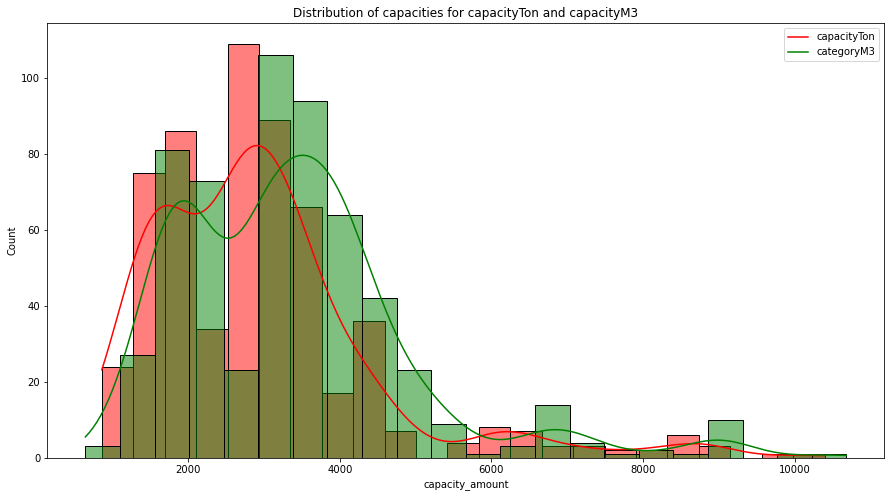

```python
comparisonTonnageVolume(df,'red', 'green')
```

### Vizualisation of the results

As we can see in the comparison between capacity ton and volume the whole dataset is filled. Furthermore, the distributions of the ton and volume are similar in form as they were in the incomplete set. Although we couldn't be sure the test set was a good representatie of the population, it does seem that it was.

### Regarding the business questions

For this research we’ve used the database of vessel finder and extracted approximately 600 barges. We’ve seen that this database wasn't complete. It had some missing information, especially about the capacity ton and volume.

By using the python libraries pandas and sklearn we're able to store the data in a csv file

## Deployment

```python
df.to_csv("barges_database.csv")
```